# Assignment 6

In this assignment, you'll analyze a collection of data sets from the [San Francisco Open Data Portal](http://data.sfgov.org/) and [Zillow](https://www.zillow.com/). The data sets have been stored in the SQLite database `sf_data.sqlite`, which you can [download here](http://anson.ucdavis.edu/~nulle/sf_data.sqlite). The database contains the following tables:

| Table | Description |
| --- | --- |
| `crime` | Crime reports dating back to 2010. |
| `mobile_food_locations` | List of all locations where mobile food vendors sell. |
| `mobile_food_permits` | List of all mobile food vendor permits. More details [here](https://data.sfgov.org/api/views/rqzj-sfat/files/8g2f5RV4PEk0_b24iJEtgEet9gnh_eA27GlqoOjjK4k?download=true&filename=DPW_DataDictionary_Mobil… |
| `mobile_food_schedule` | Schedules for mobile food vendors. |
| `noise` | Noise complaints dating back to August 2015. |
| `parking` | List of all parking lots. |
| `parks` | List of all parks. |
| `schools` | List of all schools. |
| `zillow` | Zillow rent and housing statistics dating back to 1996. More details [here](https://www.zillow.com/research/data/). |

The `mobile_food_` tables are explicitly connected through the `locationid` and `permit` columns. The other tables are not connected, but you may be able to connect them using dates, latitude/longitude, or postal codes.

Shapefiles for US postal codes are available [here](https://www.census.gov/geo/maps-data/data/cbf/cbf_zcta.html). These may be useful for converting latitude/longitude to postal codes.

Shapefiles for San Francisco Neighborhoods are available [here](https://data.sfgov.org/Geographic-Locations-and-Boundaries/SF-Find-Neighborhoods/pty2-tcw4).

# Data munging : Integrating S.F. neighborhoods into our analysis

One of my interests in working with spatial data is trying to work with "areas" instead of points. Given that we have neighborhood shapefiles, I wanted to find the fascinating characteristics behind them. We have a very large dataset (crime) with many rows, but the points do not express which neighborhood each point is in. I decided to use Geopandas and do a point-in-plane with the spatial join operation. I use this extra information throughout my analysis.

```python
#Read in important packages
import sqlite3 as sql
import pandas as pd
import numpy as np
import scipy
import scipy.stats
import matplotlib.pyplot as plt
%matplotlib inline
plt.rcParams['figure.figsize'] = (12, 12)
import geopandas as gpd
import re
import shapely
```

**How I did it, initally:**

```python
#Here's my initial code I used to generate a "neighborhood" column for the crime table.
#The method used is spatial merge from GeoPandas.
#I am using the dataframe generated from this code by calling it directly from github to save running time
###########################################################
#crime_xy=pd.read_sql("SELECT Lon, Lat FROM crime",sf_data)
#crime_points=[shapely.geometry.Point(tuple(cxy)) for cxy in crime_xy.values]
#crime_points_df=gpd.GeoDataFrame(crime_points,columns=["geometry"])
#WARNING: The following operation is computationally expensive!
#neighborhoods=gpd.sjoin(crime_points_df,sf_neighborhoods,how="inner",op="within").name
#nhoodf=pd.DataFrame(neighborhoods)
```

```python
#All of the work above was saved and uploaded on GitHub. I'm saving you the trouble by putting it right here.
neighborhood_crimes=pd.read_csv("https://raw.githubusercontent.com/pvacek/UC-Davis/master/STA%20141B/Assignment%206/nhoodf.csv")
```

```python
#call in our SQL table
sf_data=sql.connect("sf_data.sqlite")
```

```python
#I'm using this code to update the initial SQL table. It may be a little slow, but the initial operation is even slower.
#Trust me on that. And no, I'm not going to use timeit because that would be incredibly slow to run.
#This operation takes about 10 minutes to run on my laptop, but the spatial join took about 20.
crime=pd.read_sql("SELECT * FROM crime",sf_data)
crime=crime.reset_index().merge(neighborhood_crimes.rename(columns={"Unnamed: 0":"index"}),on="index").drop("index",axis=1)
```

```python
#Write a new table with the neighborhood column as name so we can join it on the shapefile
crime.to_sql("crime2",sf_data,index=False)
```

**Reading in the zipcodes shapefile**: A little bit slow unfortunately due to subsetitng

```python
school_addresses=pd.read_sql("SELECT Address FROM schools",sf_data)
sf_unique_zipcodes=np.unique(np.array(["".join(re.findall("[0-9]+$",s)) for s in school_addresses.Address]))
us_zipcodes=gpd.read_file("./cb_2015_us_zcta510_500k/cb_2015_us_zcta510_500k.shp")
us_zipcodes.AFFGEOID10=pd.Series([re.sub("8600000US","",z) for z in us_zipcodes.AFFGEOID10])
sf_zips=us_zipcodes.loc[np.in1d(us_zipcodes.AFFGEOID10.values,sf_unique_zipcodes)==True]
sf_zips=sf_zips.reset_index(drop=True)
```

**Reading in the neighborhoods shapefile:** Much easier

```python
#Now let's get the neighborhood data
sf_neighborhoods=gpd.read_file("./sf_neighborhoods/geo_export_efe56c7a-957f-4456-b2e4-8bd7a000412e.shp")
```

# A view of our initial maps

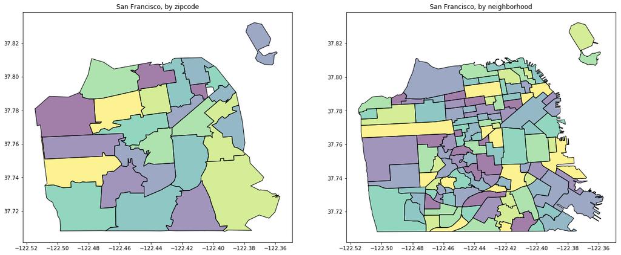

```python
plt.figure(figsize=(20, 8))
plt.subplot(1,2,1)
sf_zips.plot(ax=plt.gca())
plt.title("San Francisco, by zipcode")
plt.subplot(1,2,2)
sf_neighborhoods.plot(ax=plt.gca())
plt.title("San Francisco, by neighborhood")
plt.show()
```

**Exercise 1.1.** Which mobile food vendor(s) sells at the most locations?

```python
#Exercise 1.1
pd.read_sql("SELECT Applicant, count(Applicant) AS num_permits FROM mobile_food_permits AS mfp "
            "INNER JOIN (SELECT DISTINCT locationid, permit FROM mobile_food_schedule) "
            "AS mfs ON mfp.permit=mfs.permit WHERE mfp.Status=='APPROVED' GROUP BY mfp.Applicant "
            "ORDER BY num_permits DESC LIMIT 5",sf_data)
```

|  | Applicant | num_permits |
| --- | --- | --- |
| 0 | Park's Catering | 23 |
| 1 | D & T Catering | 17 |
| 2 | F & C Catering | 13 |
| 3 | Munch A Bunch | 10 |
| 4 | Eva's Catering | 8 |

**Answer:** Based off of our SQL query, Park's Catering sells at the most locations.

**Exercise 1.2.** Ask and use the database to analyze 5 questions about San Francisco. For each question, write at least 150 words and support your answer with plots. Make a map for at least 2 of the 5 questions.

You should try to come up with some questions on your own, but these are examples of reasonable questions:

- Which parts of the city are the most and least expensive?
- Which parts of the city are the most dangerous (and at what times)?
- Are noise complaints and mobile food vendors related?
- What are the best times and places to find food trucks?
- Is there a relationship between housing prices and any of the other tables?

Please make sure to clearly state each of your questions in your submission.

**Question 1:** Which crime types are most common around San Francisco?

For the first question in exercise 1.2, I decided to find out which crimes were the most common by neighborhood. I knew I had to use some crafty SQL techniques to do this, so I decided to select the counts from a subtable that I created with some help from group by. I also had to invoke the max function, but if I did before selecting from the sub table, there may have been some issues.

```python
common_crimes=pd.read_sql("SELECT name, Descript, max(count) AS count "
                          "FROM (SELECT name, Descript, count(name) AS count FROM crime2 GROUP BY name, Descript) "
                          "GROUP BY name",sf_data)
```

Before we take a visual examination of the data, let's how often each crime type apppeared as the maximum for each neighborhood:

```python
pd.DataFrame(common_crimes.Descript.value_counts())
```

|  | Descript |
| --- | --- |
| GRAND THEFT FROM LOCKED AUTO | 88 |
| DRIVERS LICENSE, SUSPENDED OR REVOKED | 9 |
| STOLEN AUTOMOBILE | 7 |
| PETTY THEFT SHOPLIFTING | 2 |
| JUVENILE INVOLVED | 1 |
| LOST PROPERTY | 1 |
| INFLICT INJURY ON COHABITEE | 1 |
| WARRANT ARREST | 1 |
| POSSESSION OF MARIJUANA | 1 |
| FOUND PERSON | 1 |
| UNDER INFLUENCE OF ALCOHOL IN A PUBLIC PLACE | 1 |
| CIVIL SIDEWALKS, CITATION | 1 |
| AIDED CASE, DOG BITE | 1 |
| PETTY THEFT FROM A BUILDING | 1 |
| MALICIOUS MISCHIEF, VANDALISM OF VEHICLES | 1 |

As expected, car jacking is the most common crime that appears as a maximum. However, there are some very intriguing maximums that we will have to examine visually.

**(Labeling code borrowed from StackOverflow: http://stackoverflow.com/questions/38899190/geopandas-label-polygons)**

```python
common_df=sf_neighborhoods.merge(common_crimes,on="name").dissolve(by="Descript").reset_index()
common_df.geometry=gpd.GeoSeries([shapely.ops.cascaded_union(district.buffer(.0001)) for district in common_df.geometry])
common_df['coords'] = common_df['geometry'].apply(lambda x: x.representative_point().coords[:])
common_df['coords'] = [coords[0] for coords in common_df['coords']]
```

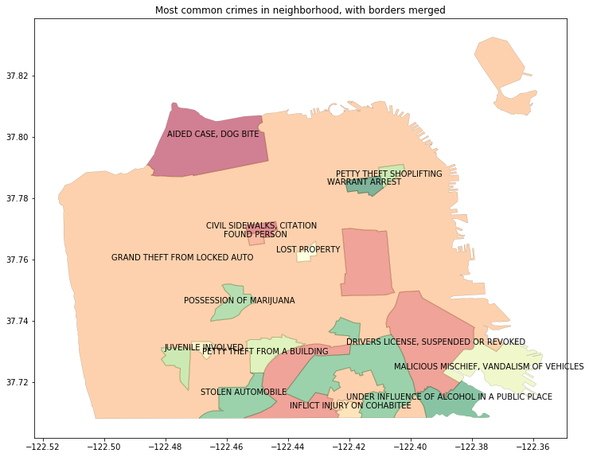

```python
common_df.plot(column="Descript",cmap="RdYlGn",linewidth=0.1)
for idx, row in common_df.iterrows():
    plt.annotate(s=row['Descript'], xy=row['coords'],
                 horizontalalignment='center')
plt.title("Most common crimes in neighborhood, with borders merged")
plt.show()
```

**Conclusion:** The results we have derived from the plot above show some very interesting results for neighborhoods that do not have car jacking as their highest crime. The Tenderloin district has shoplifting as its most common crime, this indicates that the district is likely more commercial than residential. Meanwhile there are some amusing results, such as marijuana possession appearing and also the dog bite result at Presidio.

**Question 2:** How do the arrest rates look across San Francisco? Which neighborhood has the highest percentage of arrests?

For this two-pronged question, I could answer it with a single set of data. Although I did have issues with trying to generate a fraction directly from the query, so I had to do two separate queries. The strategy behind the queries is to select the total number of crimes for each neighborhood, and then to also find the number of crimes where the resolution was a booked arrest. From this, we derive some fascinating results.

```python
totals=pd.read_sql("SELECT name, sum(total) AS all_crime FROM (SELECT name, Resolution, count(name) AS total FROM crime2 "
            "GROUP BY Resolution, name) GROUP BY name",sf_data)
arrests=pd.read_sql("SELECT name, total AS arrests FROM (SELECT name, Resolution, count(name) AS total FROM crime2 "
            "GROUP BY Resolution, name) WHERE Resolution == 'ARREST, BOOKED' GROUP BY name",sf_data)
arrest_rates=totals.merge(arrests,on="name")
arrest_rates["arrest_rate"]=arrest_rates.arrests/arrest_rates.all_crime
```

We can start by checking the top 10 neighborhoods, to get an idea if the highest arrest neighborhood is much higher.

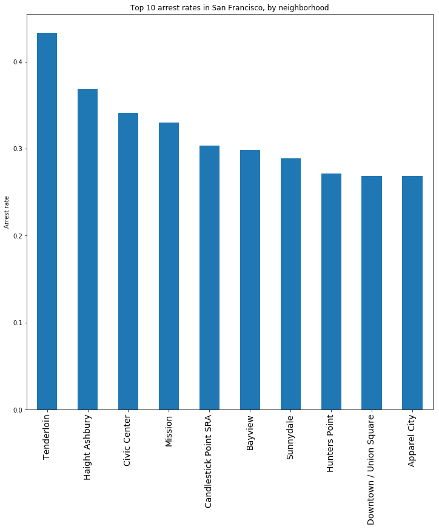

```python
arrest_sort=arrest_rates.sort_values(by="arrest_rate",ascending=False).head(10)
arrest_sort.arrest_rate.plot(kind="bar")
plt.xticks(list(range(len(arrest_sort))), arrest_sort.name, rotation=90, fontsize = 14)
plt.ylabel("Arrest rate")
plt.title("Top 10 arrest rates in San Francisco, by neighborhood")
plt.show()
```

As we noticed from question 1, the Tenderloin district had a unique common crime. This might explain why it has such a high arrest rate. The issue from this analysis arises from the fact that the arrest rate is very dependent on crime, so the higher rates are probably explained by a presence of certain crimes happening. At the same time, the police department might also have an effect on the arrest rate or crime type.

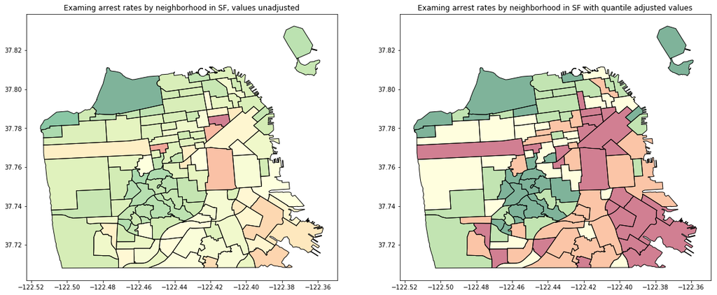

```python
arrest_plot=sf_neighborhoods.merge(arrest_rates,on="name",how="left").fillna(0)
plt.figure(figsize=(20, 8))
plt.subplot(1,2,1)
arrest_plot.plot(ax=plt.gca(),column="arrest_rate",cmap="RdYlGn_r")
plt.title("Examing arrest rates by neighborhood in SF, values unadjusted")
plt.subplot(1,2,2)
arrest_plot.plot(ax=plt.gca(),column="arrest_rate",cmap="RdYlGn_r",scheme="quantiles")
plt.title("Examing arrest rates by neighborhood in SF with quantile adjusted values")
plt.show()
```

For some visual analysis, I decided to visualize the rate by value and by quantile. By visualizing the quantiles, we can see some "natural clusters" of the crime rate across San Francisco, especially in the southeastern area.

**Question 3:** How good are the police departments at handling crimes in their own district? Are the police departments of San Francisco homogenous or heterogenous in their treatment of crime?

For the first part of question 3 I wanted to find a way to determine what neighborhoods are covered by each police district. I also wanted to measure how often the respective departments "cover" their own district, as in they don't get help from other districts. The strategy I'm using involves another invoking of the max function. I considered a neighborhood "covered" by a police district if the number of crime reports was highest with that district. I went through and used some geopandas techniques that involved "buffering" and "cascading" to combine neighborhood polygons. The plot result is below after the code.

**How well do the respective police departments handle cases in their own districts?**

```python
#Generate a SQL query that does the following: determine the police department that serves the neighborhood
districts=pd.read_sql("SELECT name, PdDistrict, max(total) AS dept_cases, sum(total) AS total_cases "
            "FROM (SELECT PdDistrict, name, count(name) "
            "AS total FROM crime2 GROUP BY PdDistrict, name ORDER BY name) GROUP BY name",sf_data)
#Aggregate the data frame into districts with dissolve and only keep district and geometry
sfpd_df=sf_neighborhoods.merge(districts,how="outer",on="name").dissolve(by="PdDistrict")
sfpd_df=sfpd_df.reset_index().rename(columns={"index":"PdDistrict"}).iloc[:,0:2]
sfpd_df.geometry=gpd.GeoSeries([shapely.ops.cascaded_union(district.buffer(.0001)) for district in sfpd_df.geometry])
#Unfortunately geopandas cannot properly do numerical aggregation, so I had to invoke pandas here
district_cases=sf_neighborhoods.merge(districts,how="outer",on="name").groupby("PdDistrict").sum().reset_index()
sfpd_df=sfpd_df.merge(district_cases,on="PdDistrict")
sfpd_df["case_rate"]=sfpd_df.dept_cases/sfpd_df.total_cases
```

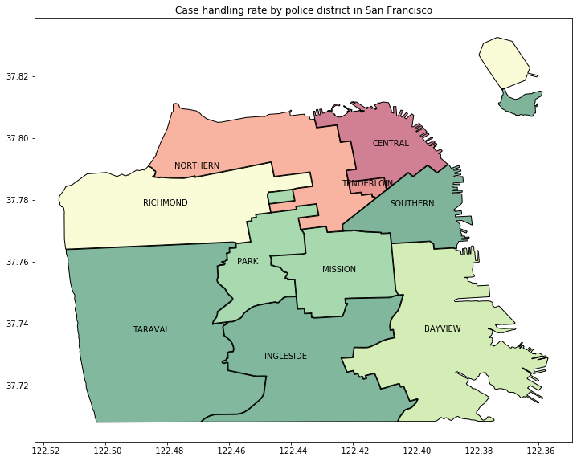

```python
sfpd_df['coords'] = sfpd_df['geometry'].apply(lambda x: x.representative_point().coords[:])
sfpd_df['coords'] = [coords[0] for coords in sfpd_df['coords']]
sfpd_df.plot(column="case_rate",cmap="RdYlGn")
for idx, row in sfpd_df.iterrows():
    plt.annotate(s=row['PdDistrict'], xy=row['coords'],
                 horizontalalignment='center')
plt.title("Case handling rate by police district in San Francisco")
plt.show()
```

It appears that the residential districts, covered by Taraval and Ingleside are much more likely to handle their own cases. Another obvious factor that appears to be affecting the coverage rate is how large the district is itself, and how many bordering districts it has.

**Which crimes receive more heterogenous discipline?** The next question involves doing some statistical analysis. I wanted to measure the dependence of crime given that it occurs in a given police district. I decided to use Pearson's Chi-sqaured statistic. Although the statistic cannot determine which district is causing the dependence, we can use it as a way to find interesting crime treatments in San Francisco. The plot result is at the end of the code.

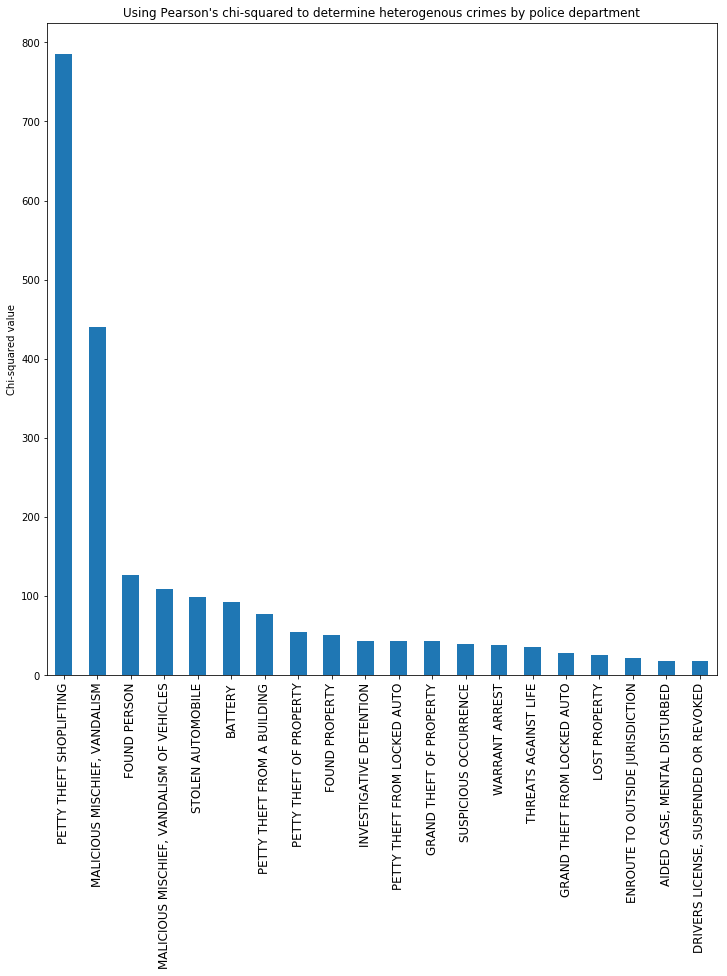

```python
#Create a generalized query function to get Pearson's chi-squared for the top 20 crime descriptions
def findChisq(description):
    crimetable=pd.read_sql("SELECT PdDistrict, Resolution, count(PdDistrict) AS numcrimes FROM crime2 WHERE Resolution IN('ARREST, BOOKED', "
            "'NONE') AND Descript=='"+description+"' GROUP BY PdDistrict, Resolution",sf_data)
    chi2,p,dof,ex=scipy.stats.chi2_contingency(crimetable.pivot(values="numcrimes",index="PdDistrict",columns="Resolution"),correction=True)
    return([description,chi2,p])

common_descs=pd.read_sql("SELECT Descript, count(Descript) FROM crime2 GROUP BY Descript ORDER BY count(Descript) DESC LIMIT 20",sf_data)

chisq_crimes=[findChisq(d) for d in common_descs.Descript]
chisq_crime_df=pd.DataFrame(np.array(chisq_crimes),columns=["crime","chisq","pvalue"])
chisq_crime_df["chisq"]=np.array(chisq_crime_df.chisq,dtype="float")

chisort=chisq_crime_df.sort_values(by="chisq",ascending=False)
chisort.chisq.plot(kind="bar")
plt.xticks(list(range(len(chisort))), chisort.crime, rotation=90, fontsize = 12)
plt.ylabel("Chi-squared value")
plt.title("Using Pearson's chi-squared to determine heterogenous crimes by police department")
plt.show()
```

We have discovered that shoplifting and vandalism are highly dependent by department. This result is a very fascinating outlier and we will use it for question 4.

**Question 4:** Which police departments are 'tough' and 'soft' on shoplifting and vandalism? Are there different patterns for arrest rates for certain crimes?

For the fourth question, I decided to dig deeper into our result from question 3. I wanted to derive further characteristics about the police departments, so I decided to examine which departments were causing the chi-square outlier results, plus more. I started off by generating a function that gets the arrest rates for a given crime description. The plot result delivers us an answer to the massive chi squared values.

```python
def getProportions(crime):
    crime_counts=pd.read_sql("SELECT PdDistrict, Resolution, count(PdDistrict) AS numcrimes FROM crime2 WHERE Resolution IN('ARREST, BOOKED', "
            "'NONE') AND Descript=='"+crime+"' GROUP BY PdDistrict, Resolution",sf_data)
    totals=crime_counts.groupby("PdDistrict").numcrimes.apply(sum,axis=0).values
    crime_counts=crime_counts[crime_counts.Resolution=="ARREST, BOOKED"]
    crime_counts["arrest_rate"]=crime_counts.numcrimes.values/totals
    crime_counts=crime_counts.drop(["numcrimes","Resolution"],1)
    crime_count_df=sfpd_df.merge(crime_counts,on="PdDistrict")
    return(crime_count_df)
```

```python
shoplifting=getProportions("PETTY THEFT SHOPLIFTING")
vandalism=getProportions("MALICIOUS MISCHIEF, VANDALISM")
```

**Finding the casaution behind the shoplifting and vandalism chi-squared values:**

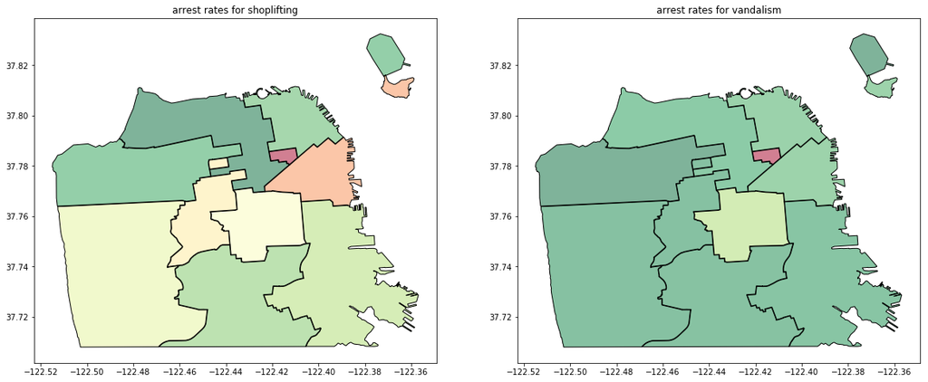

```python
plt.figure(figsize=(20, 8))
plt.subplot(1,2,1)
shoplifting.plot(ax=plt.gca(),column="arrest_rate",cmap="RdYlGn_r")
plt.title("arrest rates for shoplifting")
plt.subplot(1,2,2)
vandalism.plot(ax=plt.gca(),column="arrest_rate",cmap="RdYlGn_r")
plt.title("arrest rates for vandalism")
plt.show()
```

**Analysis:** The Tenderloin district is like causing the significantly large chi-squared values. It has a much larger arrest rate for both crime types which indicates that it is exceptionally tough on shoplifting and vandalism. Although this makes sense because shoplifting is the most common crime in the neighborhood. Meanwhile, the northern district is much less likely to arrest for shoplifting.

**Finding crimes that departments "over" arrest at:**

For the second part of the question, I decided to find characteristics about departments that were not the Tenderloin department. For the top 20 crime categories, I derived the rank a police department has for its arrest rate. I also derived a margin that measures the difference from the interdepartmental median arrest rate for each crime. I used these results to generate a table which shows the highest margin for each department.

```python
def findRanks(crime_desc):
    crime_data=getProportions(crime_desc)
    crime_data["margin"]=crime_data.arrest_rate-np.median(crime_data.arrest_rate)
    crime_sort=crime_data.sort_values(by="arrest_rate")
    crime_sort["rank"]=crime_sort.reset_index().index.values+1
    crime_stats=crime_sort[["PdDistrict","arrest_rate","rank","margin"]]
    crime_stats.index=[crime_desc]*10
    return(crime_stats)
```

```python
district_crime_ranks=[findRanks(cd) for cd in common_descs.Descript]
```

```python
rank_df=pd.concat(district_crime_ranks).reset_index().rename(columns={"index":"Descript"})
rank_df.sort_values(by='rank', ascending=False).groupby("PdDistrict",as_index=False).first()
```

|  | PdDistrict | Descript | arrest_rate | rank | margin |
| --- | --- | --- | --- | --- | --- |
| 0 | BAYVIEW | PETTY THEFT OF PROPERTY | 0.018836 | 10 | 0.010352 |
| 1 | CENTRAL | GRAND THEFT FROM LOCKED AUTO | 0.004006 | 7 | 0.000465 |
| 2 | INGLESIDE | ENROUTE TO OUTSIDE JURISDICTION | 0.943098 | 8 | 0.002476 |
| 3 | MISSION | LOST PROPERTY | 0.004705 | 10 | 0.003165 |
| 4 | NORTHERN | ENROUTE TO OUTSIDE JURISDICTION | 0.951299 | 10 | 0.010677 |
| 5 | PARK | THREATS AGAINST LIFE | 0.360078 | 10 | 0.041674 |
| 6 | RICHMOND | AIDED CASE, MENTAL DISTURBED | 0.053068 | 9 | 0.017190 |
| 7 | SOUTHERN | SUSPICIOUS OCCURRENCE | 0.021237 | 9 | 0.007650 |
| 8 | TARAVAL | AIDED CASE, MENTAL DISTURBED | 0.054478 | 10 | 0.018601 |
| 9 | TENDERLOIN | PETTY THEFT SHOPLIFTING | 0.704974 | 10 | 0.315241 |

As we can see, there is a large variation in the categories for this result. This means there may be some interesting maps when we plot the rankings for a given crime. Let's examine the ranking for arrest rased based on mentally disturbed cases and property theft.

```python
disturbed=sfpd_df.merge(rank_df[rank_df.Descript=="AIDED CASE, MENTAL DISTURBED"],on="PdDistrict")
petty=sfpd_df.merge(rank_df[rank_df.Descript=="PETTY THEFT OF PROPERTY"],on="PdDistrict")
```

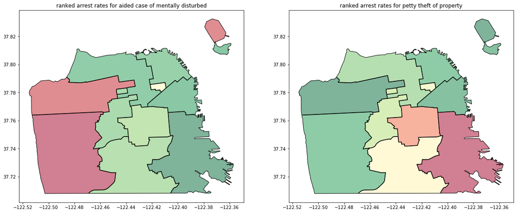

```python
plt.figure(figsize=(20, 8))
plt.subplot(1,2,1)
disturbed.plot(ax=plt.gca(),column="arrest_rate",cmap="RdYlGn_r")
plt.title("ranked arrest rates for aided case of mentally disturbed")
plt.subplot(1,2,2)
petty.plot(ax=plt.gca(),column="arrest_rate",cmap="RdYlGn_r")
plt.title("ranked arrest rates for petty theft of property")
plt.show()
```

**Conclusion:** The arrest rates indicate a fascinating pattern, such that certain crimes may be "less acceptable" in areas of San Francisco, and it may depend on whether the neighborhood areas are residential or commercial.

**Question 5:** Which neighborhoods are the most 'covered' by food trucks?

For my last question, I decided to examine something that was less about crime, and more lighthearted. I made use of food truck data to determine the locational spread of food trucks. I also wanted to demonstrate some fascinating geographic manipulation methods in geopandas. I decided to derive how much of the area of a neighborhood was "covered" by food trucks. Below is my result of the locations of food trucks, and their corresponding "radii".

```python
food_locs=pd.read_sql("SELECT * FROM mobile_food_locations AS mfl INNER JOIN "
                      "mobile_food_schedule AS mfs ON mfl.locationid=mfs.locationid "
                      "INNER JOIN mobile_food_permits AS mfp ON mfs.permit=mfp.permit "
                      "WHERE Latitude > 0 AND Longitude < 0 AND Status=='APPROVED'",sf_data)
food_xy=pd.read_sql("SELECT Longitude,Latitude FROM mobile_food_locations AS mfl INNER JOIN "
                      "mobile_food_schedule AS mfs ON mfl.locationid=mfs.locationid "
                      "INNER JOIN mobile_food_permits AS mfp ON mfs.permit=mfp.permit "
                      "WHERE Latitude > 0 AND Longitude < 0 AND Status=='APPROVED' GROUP BY mfl.locationid",sf_data)
food_locs=food_locs.reset_index(drop=True)
```

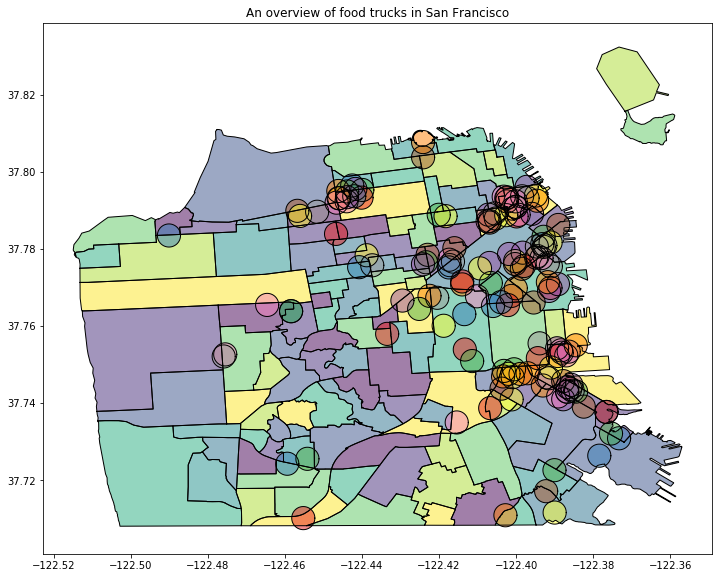

```python
food_points=gpd.GeoDataFrame([shapely.geometry.Point(tuple(f)) for f in food_xy.values],columns=["geometry"])
base=sf_neighborhoods.plot()
food_points.buffer(0.003).plot(ax=base)
plt.title("An overview of food trucks in San Francisco")
plt.show()
```

The food trucks are clustered in eastern San Francisco, which gives us a good idea of where the downtown is, and the more commercial areas. For the next part, I derived the food truck coverage rate by using "geometric differencing", the results regarding food trucks and the percentage of area covered by neighborhood are below.

```python
food_union=food_points.buffer(.003).unary_union
food_holes=sf_neighborhoods["geometry"].difference(food_union)
food_coverage_rate=1-food_holes.area/sf_neighborhoods.area
nh_food=sf_neighborhoods.loc[gpd.sjoin(food_points,sf_neighborhoods,how="inner",op="within").index_right].name.value_counts()
nh_food_df=pd.DataFrame(nh_food).reset_index().rename(columns={"index":"name","name":"numtrucks"})
food_stats=pd.concat([sf_neighborhoods.merge(nh_food_df,how="outer"),food_coverage_rate],axis=1).rename(columns={0:"food_cover_rate"})
food_stats=pd.DataFrame(food_stats.fillna(0))
```

**Which neighborhoods have the most food trucks?**

```python
food_stats.sort_values(by="numtrucks",ascending=False).iloc[:,2:].head()
```

|  | name | numtrucks | food_cover_rate |
| --- | --- | --- | --- |
| 30 | South of Market | 16.0 | 0.676635 |
| 107 | Financial District | 15.0 | 0.909987 |
| 73 | India Basin | 11.0 | 0.812865 |
| 53 | Central Waterfront | 11.0 | 0.436245 |
| 82 | Produce Market | 10.0 | 0.825983 |

**Which neighborhoods have the highest food truck coverage rates?**

```python
food_stats.sort_values(by="food_cover_rate",ascending=False).iloc[:,2:].head()
```

|  | name | numtrucks | food_cover_rate |
| --- | --- | --- | --- |
| 17 | Downtown / Union Square | 7.0 | 0.965542 |
| 31 | Showplace Square | 4.0 | 0.929757 |
| 107 | Financial District | 15.0 | 0.909987 |
| 19 | Civic Center | 3.0 | 0.872834 |
| 79 | Apparel City | 1.0 | 0.862729 |

**What is the relationship between food truck count and coverage rate?**

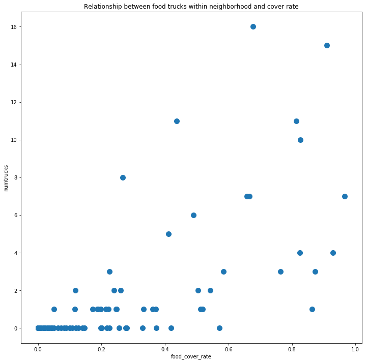

```python
food_stats.plot(kind="scatter",x="food_cover_rate",y="numtrucks",s=100)
plt.title("Relationship between food trucks within neighborhood and cover rate")
plt.show()
```

Based on our plot, we could potentially estimate an exponential relationship between the number of food trucks and the coverage rate. Nonetheless, it is interest how some neighborhoods with no food trucks have many adjacent ones, as evidenced by the high cover rates.

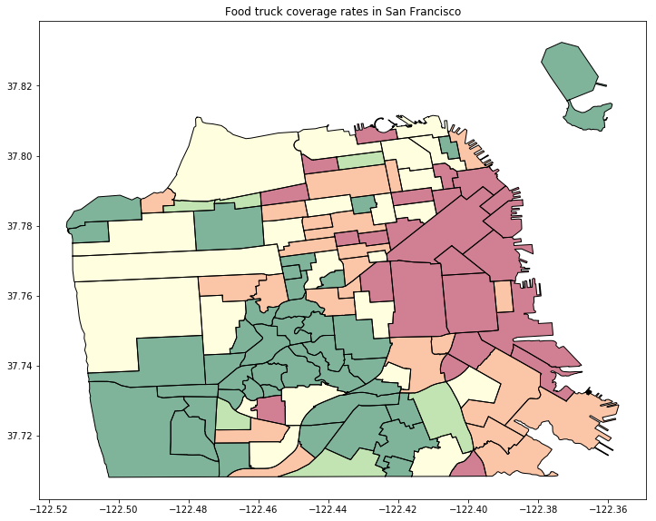

```python
gpd.GeoDataFrame(food_stats).plot(column="food_cover_rate",cmap="RdYlGn_r",scheme="quantiles")
plt.title("Food truck coverage rates in San Francisco")
plt.show()
```

For my final plot, I decided to map out the coverage rates across San Francisco. We can observe some nice, well grouped clusters based on this, and it may as well be a plot that indicates which areas or more or less commercial.

# My final line of Python code for this class. Thanks for the assignments! Also I probably spent at least 50 hours on this assignment :( I had too much fun.

```python
sf_data.close()
```